# Borrador. La afiliación sindical en las empresas chilenas. Un análisis multinivel utilizando la Encla 2014

Nicolás Ratto

viernes 16 octubre 2020 17:13:29

# 1 RESUMEN

La presente investigación busca estimar el efecto que el poder estructural y social de los trabajadores, en las ramas económicas y en las empresas, generan sobre la tasa de afiliación de los sindicatos de Chile en 2014. Es decir, se busca conocer porque algunos sindicatos son más representativos que otros al interior de las empresas, recurriendo a la segunda ola del enfoque de los recursos de poderes de los trabajadores y a las teorías de la revitalización sindical (Frege and Kelly 2004; Ross 2007). Esto, en el contexto chileno, caracterizado por sus bajos niveles de afiliación sindical y de cobertura en la negociación colectiva, de debilidad institucional de los trabajadores y de una acción sindical legalista y centrada en el nivel de empresa. En específico, se busca dar respuesta a preguntas como ¿La tasa de afiliación sindical se ve afectada por las alianzas que construyen los sindicatos con organizaciones supra sindicales?, ¿Influyen el tipo de relación que sostienen con sus empleadores?, ¿Influyen características de la empresa como su tamaño, el número de sindicatos en su interior o la presencia de conflictos colectivos?, ¿Qué tanto difieren estos aspectos entre las distintas ramas de actividad económica? Para esto, se construyeron una serie de modelos multinivel a partir de la Encuesta Laboral Encla 2014, específicamente a partir de la base de datos de cuestionarios aplicados a Dirigentes Sindicales (N = 717). Se concluye que, el poder estructural en el lugar de trabajo que tienen los trabajadores en las ramas económicas afecta positiva y significativamente los niveles de la afiliación sindical en las empresas chilenas (controlando incluso por tamaño de empresa) y que, al nivel de empresa, la afiliación sindical aumenta a mayor subordinación del sindicato a la empresa y a menor número de organizaciones sindicales paralelas.

**Palabras claves**: sindicalismo, poder estructural, empresa, afiliación sindical, Chile.

[Respositorio github](https://github.com/nicolasrattor/Tasa_sindicalizacion_encla2014/)

# 2 Introducción

Uno de los mayores consensos de los estudios del trabajo sobre Chile es que las relaciones laborales en el país se encuentran desequilibradas en perjuicio de los trabajadores y trabajadoras (Aguilar, Henriquez, and Pérez 2017; Campusano et al. 2017; Dirección del Trabajo 2015; Julián 2018; Ramos 2016), especialmente por la estructura político-institucional heredada de dictadura que regula hasta el día de hoy el trabajo y, por los cambios socioeconómicos y de las formas de organizar la producción que ha sufrido el país en los últimos cuarenta años. La debilidad del trabajo frente al capital se expresa en la profunda desigualdad social y económica que atraviesa al país (PNUD 2017) y en la debilidad de los actores colectivos de defensa de los derechos de los trabajadores y trabajadoras: desde el retorno a la democracia la tasa de afiliación sindical en el país no ha superado el 20% de los asalariados del sector privado, las negociaciones colectivas tienen una cobertura aún más baja y se encuentran ultra reguladas en sus tiempos, formas y alcances de que cuestiones negociar y, el mencionado sindicalismo ha centrado su acción en el nivel de empresa, de manera despolitizada y atomizada (Álvarez 2017; Calderón 2008).

Pese a esta imagen general de debilidad, a lo menos en los últimos diez años diversas investigaciones de caso, o por ramas de actividad económica, han identificado novedosos procesos de organización sindical: masivos, politizados y efectivos en el logro de sus objetivos (Aravena and Núñez 2009; Henriquez 2017; Ratto 2019; Santibáñez and Gaudichaud 2017). Pero también, otros tanto estudios han mostrado la dificultad de la construcción y del sostenimiento de la organización sindical (Calderón 2008; Urrutia, Osorio, and Campusano 2015), e incluso, han buscado explicar la ausencia de la misma y del conflicto (Baeza, Medel, and Olea 2017). Ante tal diversidad de experiencias particulares en las diferentes ramas, resulta pertinente recurrir a fuentes estadísticas para tener una idea de la representatividad de cada una de estas experiencias, como también, conocer y medir el efecto de diferentes elementos al nivel de empresa y de la rama económica que podrían estar influyendo en que unos sindicatos tengan más poder que otros al interior de las empresas. Así, el objetivo general de la presente investigación queda definido como estimar el efecto que el poder estructural y social de los trabajadores, en las ramas económicas y en las empresas, generan sobre la tasa de afiliación de los sindicatos de Chile en 2014.

El poder, en el marco del análisis de clase, puede ser teorizado como la capacidad de las personas y las organizaciones de realizar sus intereses de clase (Wright 2018, 101:225). Este último autor ha identificado dos grandes tipos de poder de la clase obrera: el “poder asociativo”, que resulta de la formación de organizaciones colectivas de trabajadores, como sindicatos, partidos y consejos de trabajadores; y el “poder estructural”, que resulta de la ubicación de los trabajadores en el sistema económico, tanto en el mercado laboral como en el lugar de trabajo (Wright 2000).

El poder asociativo tradicionalmente ha sido medido a través del número de socios sindicales (Frege and Kelly 2004), siendo considerado por los autores uno de los cuatro elementos principales para identificar procesos de revitalización sindical. Si bien un alto número o porcentaje de socios sindicales no garantiza un alto poder o una representatividad real de los sindicatos al interior de las empresas (Gutiérrez 2016), este es un indicador sencillo de construir, ampliamente utilizado por la literatura y, disponible en registros administrativos y en encuestas laborales chilenas [Dirección del Trabajo (2015), Dirección del Trabajo (2018); Salinero, Rozas, and Tapia (2006)).

Uno de los más evidentes elementos que gatillan que los sindicatos en términos individuales sean menos representativos al nivel de empresa, y que tengan menos poder, es el paralelismo sindical. Es decir, la posibilidad de que en la empresa exista y negocie más de un sindicato con el empleador y, por ende, que los trabajadores de una empresa se repartan y dividan entre las distintas organizaciones sindicales. Chile es uno de los pocos países de América Latina y el mundo en los que el paralelismo sindical al nivel de empresa es permitido y promovido por la institucionalidad laboral (FundaciónSol 2015; Piñera 1992).

*H1 (nivel 1): a mayor número de sindicatos al interior de las empresas chilenas, menor será la afiliación sindical de cada uno de estos sindicatos, controlando por el número de trabajadores en la empresa.*

El poder estructural de los trabajadores tiene dos dimensiones: el poder en el mercado laboral, que dependerá de los niveles de desempleo, de las calificaciones de los trabajadores y de los ingresos alternativos a los que reciben por su trabajo asalariado; y el poder en el lugar de trabajo, que dependerá de la centralidad económica de las actividades de los trabajadores y trabajadoras para la producción y circulación de mercancías (Silver 2003; Wright 2000). Para operacionalizar el poder de los trabajadores en los mercados de trabajo se utilizará la variable “Tasa de Cesantía” en las ramas de actividad económica, mientras que para operacionalizar el segundo poder se utilizará la variable “PIB por Trabajador” en cada una de las mismas.

*H2 (nivel 2): mientras mayor sea el peso de cada trabajador en el producto interno bruto de las ramas de actividad económica, mayor será la tasa de afiliación sindical en las empresas de las ramas.*

*H3 (nivel 2): mientras mayor es la tasa de desempleo en las ramas de actividad económica en las que se desarrollan las empresas, menor será la tasa de afiliación a los sindicatos de aquellas empresas.*

Si bien Wright (2018) menciona y advierte que el poder estructural puede influir en el poder asociativo, su objetivo es teorizar los efectos del poder asociativo de los trabajadores sobre los “intereses capitalistas” y sobre los “compromisos de clase”. Estos compromisos son establecidos entre la clase obrera y la clase capitalista en contextos institucionales específicos, como las empresas, los mercados o los Estados. Estos mismos compromisos pueden ser pensados como recursos de poder institucionales que encuadran las disputas de clase y que son movilizados por los actores en conflicto con el fin de materializar sus propios intereses (Dörre, Holst, and Nachtwey 2009). En el presente texto los recursos de poder institucionales a nivel estatal son considerados como un contexto común a todas las organizaciones sindicales de la muestra.

Un cuarto y último gran tipo de poder ha sido identificado por la “segunda ola” de las teorías de los recursos de poder (Ludwig, Webster, and Schmalz 2018; Schmalz 2017): el poder social o cooperativo de los trabajadores que consiguen al movilizar alianzas sociales y políticas. Este último gran poder ha sido caracterizado por algunos enfoques como un punto de convergencia entre las diferentes estrategias sindicales a nivel internacional: ante la erosión de las instituciones de las relaciones industriales bajo el neoliberalismo, los trabajadores se movilizarían mediante movimientos sociales y sindicales amplios, cuyas organizaciones y demandas van más allá de las clásicamente laborales (Gasparri, Ikeler, and Fullin 2018; Tattersall 2013). De esta forma “movimientista”, las organizaciones sindicales conseguirían revitalizarse, sumar nuevos adherentes y recuperar su poder. Ante la falta de preguntas en la encuesta Encla 2014 sobre alianzas sindicales con actores sociales y políticos más allá de lo laboral, como proxy al poder social se ocuparán las variables que preguntan por alianzas sindicales con organizaciones suprasindicales.

*H4 (nivel 1): los sindicatos que participan de federaciones y/o confederaciones (organizaciones suprasindicales) desarrollarán un mayor poder asociativo que aquellos que no participan de estas organizaciones.*

Otra tesis similar y que a veces entronca con la línea del sindicalismo “comunitario” o “social”, es la del sindicalismo politizado, radical, clasista o militante (Bacon and Blyton 2002; Ross 2007; Connolly and Darlington 2012). Estos autores insisten en que una de las claves para la revitalización sindical está en que los sindicatos utilicen estrategias disruptivas y discursos clasistas para conseguir sus objetivos. Si bien la encuesta Encla 2014 no tiene mediciones sobre la conflictividad de los sindicatos en particular, tiene un proxy que mide la conflictividad laboral en cada una de las empresas y la actitud de las empresas frente a los sindicatos. Como un acercamiento, muy imperfecto, a la politización de los sindicatos, se utilizarán las variables de conflictividad laboral en la empresa y actitud de la empresa hacia la acción sindical.

*H5 (nivel 1): los sindicatos de las empresas que hayan tenido conflictos colectivos en los últimos doce meses tendrán una mayor tasa de afiliación que aquellos de empresas que no hayan tenido conflictos colectivos.*

*H6 (nivel 1): Cuando las empresas tienen actitudes que dificultan la acción sindical mayor será la tasa de afiliación sindical (en tanto se supone que esta acción evidenciaría o generaría conflicto en la empresa).*

La contracara de estas alianzas “entre los de abajo”, son las alianzas que eventualmente pueden organizar los sindicatos con “los de arriba”, de las cuales algunos han señalado que también pueden sacar provecho (Palacios-Valladares, 2010). De todas formas, en general la literatura ha señalado que la subordinación de los trabajadores a las acciones e intereses de las empresas debilitaría a los sindicatos en tanto dejarían de representar genuinamente los intereses de los trabajadores.

*H7 (nivel 1): Mientras más actividades son realizadas por los sindicatos bajo la subordinación de las empresas menor será la tasa de afiliación sindical.*

Otro proxy con el que se puede indagar la relación de subordinación del sindicato a la empresa es el tipo de instrumento colectivo que pactan periódicamente empleadores y trabajadores mediante negociaciones colectivas. Los convenios colectivos, en contraste con los contratos colectivos, no implican tiempos de negociación, fueros sindicales ni derecho a huelga para los trabajadores (Dirección del Trabajo 2015), por lo que tienden a ser utilizados por sindicatos cercanos a la empresa y en general subordinados a esta (Gamonal 2015).

*H8 (nivel 1): los sindicatos que firman convenios colectivos en vez de contratos colectivos en sus negociaciones tendrán una menor tasa de afiliación sindical que los que firman los segundos instrumentos.*

# 3 Datos, variables y métodos

Los datos analizados del nivel 1 provienen de la Encuesta Laboral Encla 2014 de la Dirección del Trabajo. Esta encuesta busca conocer y diagnosticar las condiciones de trabajo y empleo, y las relaciones laborales, de las empresas en Chile mediante la aplicación de cuestionarios a gerentes de recursos humanos, trabajadores y sindicatos. La encuesta el año 2014 se aplicó en 3.374 empresas, las que fueron seleccionadas para ser representativas de 14 ramas económicas (según CIIU 2012 , de las quince regiones del país de ese entonces y de cuatro tamaños de empresas con cinco o más trabajadores o trabajadoras). La Encla consta de cuatro tipos de cuestionarios y, por ende, de cuatro bases de datos diferentes, siendo la base de los informantes “Dirigentes Sindicales” la utilizada en la presenta investigación (N = 717). Este cuestionario solo se aplica en empresas con sindicatos, al sindicato más grande o más representativo de la empresa, en caso de que haya más de un sindicato. El detalle de la distribución de las variables del nivel 1 (Encla 2014) y de su procesamiento se presenta a continuación:

Para estas 12 ramas de actividad se obtuvo información sobre su Producto Interno Bruto (PIB), sobre su cesantía y sobre sus ocupados desde las [Cuentas Nacionales del Banco Central](https://si3.bcentral.cl/estadisticas/Principal1/Excel/CCNN/trimestrales/excel.html) y la [Encuesta Nacional de Empleo](https://www.ine.cl/estadisticas/sociales/mercado-laboral/ocupacion-y-desocupacion) del Instituto Nacional de Estadística. Con estas variables se construyeron las dos variables de nivel 2 que son utilizadas en los modelos del presente texto: “PIBxTRAB” y “TasaCesantía”.

De esta forma, las variables a utilizar en los modelos son los siguientes:

**Tabla 1. Descripción de variables utilizadas en modelos**

[output not shown]

## 3.1 Descripción de los modelos a estimar

Se estimaron siete modelos utilizando las variables descritas en el Cuadro 1 y presentadas en la estructura lógica graficada en la Figura 1 (dos niveles, diez variables independientes y una dependiente). En específico: 1) modelo nulo, 2) modelo con variables del nivel uno, 3) modelo con variables del nivel dos, 4) modelo con todas las variables del nivel uno y dos, 5) modelo con las variables significativas del nivel uno y dos, 6) modelo idéntico al anterior pero con intercepto y pendiente aleatoria, y 7) modelo idéntico al anterior pero con interacción entre variables de nivel dos y nivel 1 (“PIBxTRAB” y “NumeroSindicatos”).

**Figura 1. Variables utilizadas para la estimación de los modelos multinivel**

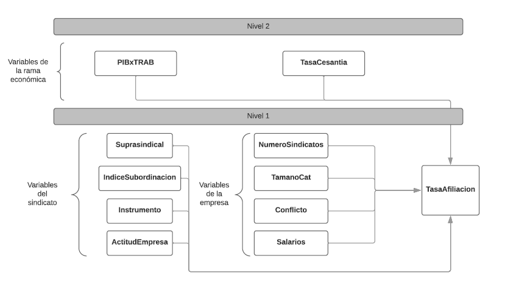

# 4 Resultados

## 4.1 Estadísticos descriptivos univariados y bivariados

Los casos válidos utilizados en los modelos varían entre 658 y 717 empresas, dependiendo de las variables utilizadas. En promedio, la tasa de afiliación sindical en las empresas de la muestra es de un 35,6% de los afiliados (linea roja en Gráfico 1), la mediana 32,0% (línea azul en Gráfico 1) y la desviación estándar de 22,9%.

**Gráfico 1. Distribución de la variable Tasa de Afiliación Sindical en la muestra**

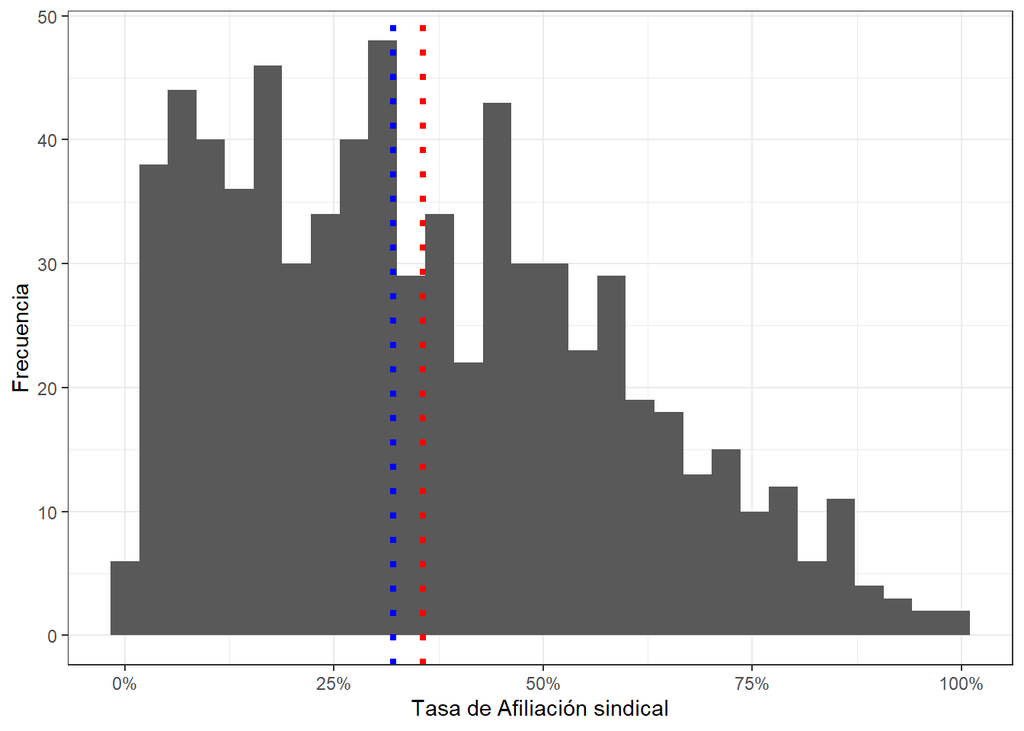

En el cuadro 1 se detalla la distribución de las variables:

La variable *Índice de Subordinación* del sindicato a la empresa tiene valores mínimo de 0 puntos (no hay subordinación del sindicato a la empresa) y valores máximos de 10 puntos (en todas las actividades que realiza el sindicato se encuentra subordinado a la empresa). En promedio los sindicatos de la muestra están poco subordinados a la empresa (2,8 puntos en promedio y 2,4 puntos de desviación estándar.

La variable *Número de Sindicatos* en la empresa tiene un valor mínimo de 1 (un sindicato en la empresa) y valores máximo de 76 (alto pluralismo sindical). En promedio, en las empresas de la muestra existen 2,2 sindicatos, siendo la desviación estándar de 5,1 sindicatos. La mediana de la variable es 1, por lo que la mitad o más de las empresas de la muestra solamente tienen un sindicato.

La variable *PIB por trabajador* en cada una de las ramas de actividad económica tiene valores mínimos de 6,2 millones de pesos por trabajador y valores máximos de 67 millones de pesos por trabajador al año. En promedio, el aporte al PIB por trabajador en todas las empresas de la muestra es de 23,8 millones de pesos y la desviación estándar es de 17,7 millones. La mediana es 19.1 millones de pesos.

Por último, respecto a las numéricas, la *tasa de cesantía* en las ramas de actividad económica durante el trimestre Octubre-Diciembre del año 2014 tiene valores mínimos de un 2,7% de los trabajadores y valores máximos de un 11,4% de los trabajadores, promediando 5,7% de cesantía y 2,3% de desviación estándar en el total de las empresas de la muestra.

Respecto a las variables categóricas, en el mismo Cuadro 1 se puede observar que el 67,5% de los sindicatos de las empresas de la muestra no se encuentran afiliados a organizaciones suprasindicales (*Suprasindical*) como Federaciones o Confederaciones; el 16% de los dirigentes de los sindicatos evalúa los salarios de su empresa (*Salarios*) como “sobre el promedio”, 22,7% bajo el promedio, 28,7% similar al promedio y 30,5% declara no haber realizado el ejercicio de comparar salarios; respecto a la variable *Instrumento*,el 55,1% de los sindicatos en su última negociación firmó contratos colectivos con la empresa, un 19,7% firmó convenios colectivos, un 4,2% no firmó ningún instrumento y un 21,1% no ha negociado colectivamente (no aplica); respecto a *Conflicto*, en un 85,6% de las empresa no ha habido conflictos colectivos en los últimos doce meses; respecto a *TamanoCat*, un 7,1% de las empresas de la muestra son micro o pequeñas empresaa, un 32,2% son medianas empresas y un 60,7% son grandes empresas; respecto a *ActitudEmpresa*, para el 62,8% de los informantes de los sindicatos la empresa da facilidades para el funcionamiento del sindicato y solamente para un 12,3% la empresa pone dificultades. Por último, se debe hacer notar que la mayoría de las empresas (24%) se encuetran en la rama de actividad económica “Servicios Sociales, Educación y Saud”, posteriormente sigue Industria Manufacturera con un 14,1%, Actividades inmobiliarias, empresariales o de alquiler con un 11,7% y Transporte, Almacenamiento y comunicaciones con un 10,2%. Las ramas con menor peso en la muestra son Agricultura (3,5%), Pesca (3,8%), Explotación de minas y canteras (3,9%) e Intermediación Financiera (4%).

Data Frame Summary

Variables_modelos

**Dimensions**: 717 x 12  
**Duplicates**: 0

| **No** | **Variable** | **Stats / Values** | **Freqs (% of Valid)** | **Graph** | **Valid** | **Missing** |
| --- | --- | --- | --- | --- | --- | --- |
| 1 | TasaAfiliacion [numeric] | Mean (sd) : 35.6 (22.9) min < med < max: 0.8 < 32 < 100 IQR (CV) : 35.4 (0.6) | 675 distinct values |  | 717 (100%) | 0 (0%) |
| 2 | IndiceSubordinacion [numeric] | Mean (sd) : 2.8 (2.4) min < med < max: 0 < 2.7 < 10 IQR (CV) : 3.6 (0.9) | 12 distinct values |  | 716 (99.86%) | 1 (0.14%) |
| 3 | NumeroSindicatos [numeric] | Mean (sd) : 2.2 (5.2) min < med < max: 1 < 1 < 76 IQR (CV) : 1 (2.3) | 23 distinct values |  | 673 (93.86%) | 44 (6.14%) |
| 4 | PIBxTRAB [numeric] | Mean (sd) : 23.9 (17.7) min < med < max: 6.2 < 19.1 < 67.1 IQR (CV) : 7.1 (0.7) | 12 distinct values |  | 717 (100%) | 0 (0%) |
| 5 | TasaCesantia [numeric] | Mean (sd) : 5.7 (2.3) min < med < max: 2.7 < 5.1 < 11.4 IQR (CV) : 4.5 (0.4) | 12 distinct values |  | 717 (100%) | 0 (0%) |
| 6 | Suprasindical [factor] | 1. Afiliado a org. suprasind 2. No afiliado a org. supras | 232 ( 32.4% ) 484 ( 67.6% ) |  | 716 (99.86%) | 1 (0.14%) |
| 7 | Salarios [factor] | 1. Sobre el promedio 2. Bajo el promedio 3. Similar al promedio 4. El sindicato no ha compar | 115 ( 16.4% ) 163 ( 23.2% ) 206 ( 29.3% ) 219 ( 31.1% ) |  | 703 (98.05%) | 14 (1.95%) |
| 8 | Instrumento [factor] | 1. Sí, contrato colectivo 2. Sí, convenio colectivo 3. No 4. No aplica | 395 ( 55.1% ) 141 ( 19.7% ) 30 ( 4.2% ) 151 ( 21.1% ) |  | 717 (100%) | 0 (0%) |
| 9 | Conflicto [factor] | 1. Ha habido conflictos cole 2. No ha habido conflictos c | 100 ( 14.0% ) 614 ( 86.0% ) |  | 714 (99.58%) | 3 (0.42%) |
| 10 | TamanoCat [factor] | 1. Micro y pequeña empresa 2. Mediana Empresa 3. Gran Empresa | 51 ( 7.1% ) 231 ( 32.2% ) 435 ( 60.7% ) |  | 717 (100%) | 0 (0%) |
| 11 | ActitudEmpresa [factor] | 1. Da facilidades para el fu 2. Ni facilita ni dificulta 3. Pone dificultades | 450 ( 62.9% ) 177 ( 24.8% ) 88 ( 12.3% ) |  | 715 (99.72%) | 2 (0.28%) |
| 12 | Actividad.y [factor] | 1. A - Agricultura... 2. B - Pesca 3. C - Explotación de minas. 4. D - Industria manufacture 5. E - Suministro de electri 6. F - Construcción 7. G - Comercio... 8. H - Hoteles y restaurante 9. I - Tra… | 25 ( 3.5% ) 27 ( 3.8% ) 28 ( 3.9% ) 101 ( 14.1% ) 36 ( 5.0% ) 39 ( 5.4% ) 64 ( 8.9% ) 39 ( 5.4% ) 73 ( 10.2% ) 29 ( 4.0% ) 256 ( 35.7% ) |  | 717 (100%) | 0 (0%) |

Generated by summarytools 0.9.6 ([R](https://www.r-project.org/) version 3.6.1)  
2020-10-16

En el Cuadro 3 se presenta la distribución de las variables ya descritas pero para el nivel 2 (ramas de actividad económica). Como se observa, hay importantes diferencias en las tasas de afiliación sindical de cada rama de actividad económica: mientras las más bajas son “Agricultura…” y “Pesca” con un 25% y 23%, respectivamente, las más altas son suministro de “Electricidad, gas y agua”, “Explotación de minas y canteras”, y “Servicios Personales, Salud y Enseñanza”, con un 50%, 43% y 40%, respectivamente. De las ramas con menor afiliación sindical destacan sus bajos niveles de PIB por trabajador (6 y 19 millones de pesos), sus relativos bajos niveles de tasa cesantía (4% y 3%), sus relativos bajos tamaños de empresa (354 y 581 trabajadores en promedio), su bajo paralelismo sindical (1,3 y 1,7 sindicatos en promedio por empresa) e Índices de subordinación a la empresa más o menos altos (2,8 y 3,4 puntos). De las dos ramas con mayor afiliación sindical destacan sus altos niveles de PIB por trabajador (67 y 54 millones de pesos), la tasa de cesantía es tanto baja como alta (3,6% contra 8,8%), los tamaños de la empresa son tanto bajos como altos (270 y 724 trabajadores), el número de sindicato es tanto alto como bajo (2,5 y 1,7 sindicatos) y el Índice de subordinación es alto (4 y 3,1 puntos).

**Tabla 3. Ramas de actividad económica utilizadas en modelo**

| Actividad | Tasa de Afiliación | PIB por trabajador | Tasa de Cesantía | Afiliados | Tamaño empresas | Número sindicatos | Índice de Subordinación |
| --- | --- | --- | --- | --- | --- | --- | --- |
| A - Agricultura… | 25.28340 | 6.203445 | 0.0426635 | 67.00000 | 354.5200 | 1.360000 | 2.763636 |
| B - Pesca | 23.74155 | 19.322275 | 0.0272785 | 110.77778 | 581.1111 | 1.703704 | 3.367003 |
| C - Explotación de minas… | 42.81073 | 67.107927 | 0.0882809 | 280.75000 | 724.0357 | 2.500000 | 3.084416 |
| D - Industria manufacturera | 34.24574 | 19.057287 | 0.0507261 | 144.50495 | 610.2970 | 1.702128 | 3.069307 |
| E - Suministro de electricidad… | 50.27935 | 54.345574 | 0.0358210 | 115.91667 | 269.9167 | 1.742857 | 4.040404 |
| F - Construcción | 28.36449 | 14.226469 | 0.0972064 | 95.58974 | 488.2308 | 1.571429 | 2.960373 |
| G - Comercio… | 30.92784 | 8.671188 | 0.0550231 | 272.45312 | 1646.8281 | 4.934426 | 2.940341 |
| H - Hoteles y restaurantes | 30.22586 | 9.875200 | 0.1137008 | 160.17949 | 771.2051 | 2.484849 | 2.144522 |
| I - Transporte… y comunicaciones | 39.59646 | 19.536794 | 0.0526609 | 170.19178 | 541.9315 | 2.750000 | 2.851806 |
| J - Intermediación financiera | 38.54576 | 40.093307 | 0.0569808 | 476.17241 | 1891.1724 | 2.304348 | 2.351097 |
| K - Actividades inmobiliarias… | 31.55184 | 52.916335 | 0.0824455 | 105.32143 | 552.6548 | 1.900000 | 2.824675 |
| Z Servicios personales, salud y enseñanza | 40.01397 | 12.460920 | 0.0369557 | 156.84884 | 522.4419 | 1.862500 | 2.402977 |

En el Cuadro 4 se observa cuales de las relaciones entre la variable dependiente Tasa de Afiliación y las mencionadas variables independientes correlacionan significativamente. Como se observa, la variable dependiente correlaciona significativamente con Índice de Subordinación (con un 95% de confianza, de manera positiva), con Tamaño de la empresa según categoría de número de trabajadores (con un 99,9% de confianza, de manera negativa), con Número de Sindicatos (con un 99,9% de confianza, de forma negativa), con Actitud de la empresa (con un 99,9% de confianza, de forma negativa) y con PIB por trabajador (con un 95% de confianza, de forma positiva). Es decir, la tasa de afiliación sindical será más alta en las empresas a mayor subordinación del sindicato a la empresa, a menor tamaño de la empresa, a menor número de sindicatos en la empresa, a mejor actitud de la empresa hacia el sindicato y mientras mayor sea el PIB por trabajar en la rama de actividad económica de la empresa. Las variables Conflicto, Instrumento, Salarios y Tasa de Cesentía no tienen una relación bivariada significativa con la tasa de afiliación sindical, con a lo menos un nivel de 95% de confianza, por lo que es esperable que tampoco sean significativas en los modelos multinivel que se presentan a continuación.

**Tabla 4. Matriz de correlaciones de variables utilizadas en modelo**

```
## Computing correlation using pearson-method with listwise-deletion...
```

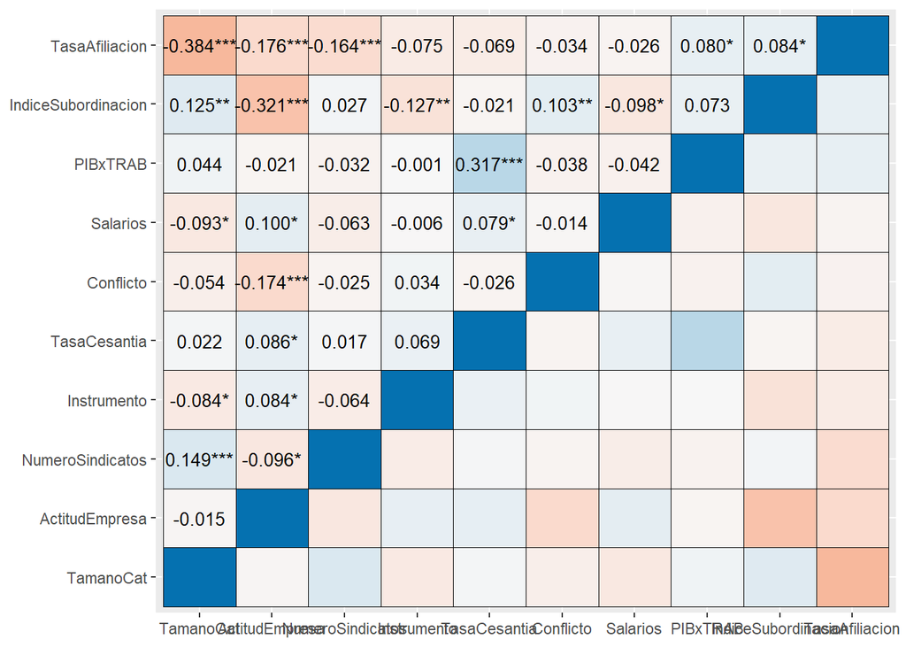

```r
library(sjPlot)
base=encla %>% select(TasaAfiliacion,IndiceSubordinacion,Conflicto,Instrumento,
                            TamanoCat,NumeroSindicatos,Salarios,ActitudEmpresa,
                            PIBxTRAB,TasaCesantia) %>% as.data.frame
base[1:10]<-sapply(base[1:10],as.numeric)
sjp.corr(base)
```

## 4.2 Modelos multinivel estimados

Los resultados indican la pertinencia de la aplicación de un modelo multinivel, pues se ha obtenido una correlación intraclase relativamente importante (ICC = 0,0806), lo que es un indicio de que existiría una dependencia contextual en los datos según rama de actividad económica. Es decir, que la afiliación sindical en las empresas de la muestra se explica en un 8% por variaciones de las ramas de actividad económica. Esto, gráficamente se observa en el Gráfico 2, donde se observan importantes diferencias en las tasas de afiliación sindical entre los sectores, contrastando, por ejemplo, Agricultura, Pesca o Construcción, cuyos sindicatos se concentran en tasas menores al 25%, mientras que Intermediación financiera, Minería o Suministro de Electricidad se concentran en tasas de sindicalización del 50% o más.

**Gráfico 2. Tasa de afiliación sindical según actividad económica**

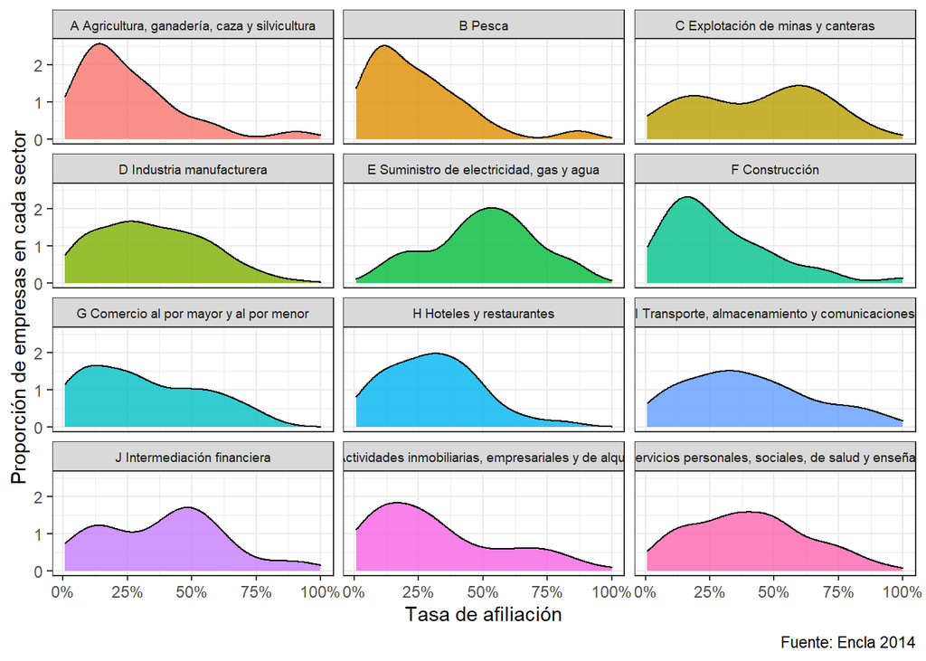

Al ocupar factor de expansión las distribuciones cambian de manera importante. Este es un punto pendiente en el presente artículo: ponderar los datos en el modelo.

**Gráfico 3. Tasa de afiliación sindical según actividad económica (expandido)**

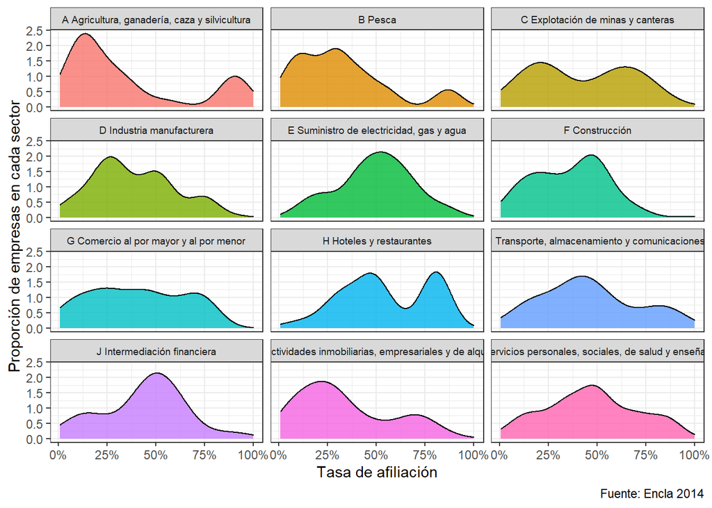

En el **modelo 2** solo se introducen como variables independientes las variables de nivel 2, de las cuáles solo “PIB por trabajador” en la rama de actividad económica es significativa, con un 95% de confianza y un valor beta de 0,22%. Esto quiere decir que por cada millón de pesos que cada trabajador aporta al PIB en cada rama de actividad económica, el porcentaje de afiliación sindical aumenta en un 0,22%. Por ejemplo, si en una rama como Agricultura el PIB por trabajador es de 6,2 millones de pesos por trabajador, y en otra como Explotación de Minas y Canteras es de 67 millones de pesos por trabajador, la tasa de afiliación sindical aumentaría en un 13,3% si un sindicato pasa de la primera a la segunda rama de actividad económica, controlando por la variable “Tasa de Cesantía” del modelo. Además, el intercepto del modelo es significativo con un 99,9% de confianza y un beta de 33,7%.

En el **modelo 3** se introducen todas las variables independientes del nivel 1 y del nivel 2. En este modelo el intercepto sigue siendo significativo con un 99,9% de confiaza y un beta de 68,3%. La significación y la dirección de los valores beta de las variables de nivel 1 y de nivel 2 son identicas a las de los modelos 2 y 3, solamente cambian los valores beta en algunas unidades porcentuales que no hacen mayores diferencias.

**Tabla 5. Modelos multinivel estimados**

|  | *Dependent variable:* |  |  |  |  |  |  |
| --- | --- | --- | --- | --- | --- | --- | --- |
|  | Tasa de sindicalización |  |  |  |  |  |  |
|  | M0 | M1 | M2 | M3 | M4 | M5 | M6 |
|  | (1) | (2) | (3) | (4) | (5) | (6) | (7) |
|  |  | NA | NA | NA | NA | NA | NA |
| SuprasindicalNo afiliado a org. suprasindical |  | -2,24 |  | -2,17 |  |  |  |
|  |  | (1,72) |  | (1,71) |  |  |  |
| SalariosBajo el promedio |  | -2,19 |  | -2,15 |  |  |  |
|  |  | (2,68) |  | (2,68) |  |  |  |
| SalariosSimilar al promedio |  | -6,38*** |  | -6,23** |  |  |  |
|  |  | (2,46) |  | (2,46) |  |  |  |
| SalariosEl sindicato no ha comparado salarios |  | -2,48 |  | -2,35 |  |  |  |
|  |  | (2,50) |  | (2,50) |  |  |  |
| InstrumentoSí, convenio colectivo |  | -1,16 |  | -1,19 |  |  |  |
|  |  | (2,10) |  | (2,10) |  |  |  |
| InstrumentoNo |  | 3,33 |  | 3,12 |  |  |  |
|  |  | (3,94) |  | (3,93) |  |  |  |
| InstrumentoNo aplica |  | -5,27** |  | -5,23** |  |  |  |
|  |  | (2,07) |  | (2,07) |  |  |  |
| ConflictoNo ha habido conflictos colectivos en la empresa |  | -5,57** |  | -5,42** | -5,33** | -5,28** | -5,18** |
|  |  | (2,31) |  | (2,31) | (2,30) | (2,28) | (2,28) |
| TamanoCatMediana Empresa |  | -17,54*** |  | -17,76*** | -16,32*** | -16,39*** | -16,46*** |
|  |  | (3,54) |  | (3,54) | (3,42) | (3,40) | (3,40) |
| TamanoCatGran Empresa |  | -30,80*** |  | -31,02*** | -29,83*** | -29,42*** | -29,59*** |
|  |  | (3,47) |  | (3,46) | (3,32) | (3,31) | (3,30) |
| NumeroSindicatos |  | -0,61*** |  | -0,60*** | -0,58*** | -1,03*** | -0,05 |
|  |  | (0,16) |  | (0,16) | (0,15) | (0,34) | (0,56) |
| PIBxTRAB:NumeroSindicatos |  |  |  |  |  |  | -0,04* |
|  |  |  |  |  |  |  | (0,02) |
| IndiceSubordinacion |  | 0,80** |  | 0,77** | 0,80** | 0,82** | 0,81** |
|  |  | (0,35) |  | (0,35) | (0,34) | (0,34) | (0,34) |
| ActitudEmpresaNi facilita ni dificulta la acción sindical |  | -4,19** |  | -4,16** | -4,64** | -4,73** | -4,85** |
|  |  | (1,99) |  | (1,98) | (1,95) | (1,93) | (1,93) |
| ActitudEmpresaPone dificultades |  | -11,18*** |  | -11,06*** | -11,87*** | -11,99*** | -12,00*** |
|  |  | (2,59) |  | (2,60) | (2,53) | (2,52) | (2,52) |
| PIBxTRAB |  |  | 0,22** | 0,18** | 0,19** | 0,20** | 0,27*** |
|  |  |  | (0,09) | (0,08) | (0,08) | (0,08) | (0,10) |
| TasaCesantia |  |  | -78,35 | -22,95 |  |  |  |
|  |  |  | (72,48) | (63,73) |  |  |  |
| Constant | 34,77*** | 71,62*** | 33,76*** | 68,32*** | 59,65*** | 59,97*** | 58,17*** |
|  | (2,13) | (4,85) | (5,14) | (6,35) | (4,67) | (4,68) | (4,93) |
| Observations | 717 | 658 | 717 | 658 | 669 | 669 | 669 |
| Log Likelihood | -3.248,56 | -2.883,61 | -3.242,01 | -2.877,85 | -2.951,16 | -2.949,47 | -2.951,07 |
| Akaike Inf. Crit. | 6.503,13 | 5.801,21 | 6.494,01 | 5.793,70 | 5.924,31 | 5.924,93 | 5.930,14 |
| Bayesian Inf. Crit. | 6.516,85 | 5.877,53 | 6.516,89 | 5.879,00 | 5.973,87 | 5.983,51 | 5.993,22 |
| *Note:* | p<0,1; p<0,05; p<0,01 |  |  |  |  |  |  |

## 4.3 Ajuste modelos

Tratamientos presentados por [Castillo (2019)](https://juancarloscastillo.github.io/jc-castillo/documents/diplomado_multinivel/d_ajuste-reporte.html).

> Cálculo R2 B&R

Extraer componentes de la varianza para cálculo de R2

```r
varcomp_0=as.data.frame(VarCorr(results_0))
tau00_0=varcomp_0[1,4]
sigma2_0=varcomp_0[2,4]

varcomp_1=as.data.frame(VarCorr(results_1))
tau00_1=varcomp_1[1,4]
sigma2_1=varcomp_1[2,4]

varcomp_2=as.data.frame(VarCorr(results_2))
tau00_2=varcomp_2[1,4]
sigma2_2=varcomp_2[2,4]

varcomp_3=as.data.frame(VarCorr(results_3))
tau00_3=varcomp_3[1,4]
sigma2_3=varcomp_3[2,4]

varcomp_4=as.data.frame(VarCorr(results_4))
tau00_4=varcomp_4[1,4]
sigma2_4=varcomp_4[2,4]

varcomp_5=as.data.frame(VarCorr(results_5))
tau00_5=varcomp_5[1,4]
sigma2_5=varcomp_5[2,4]

varcomp_6=as.data.frame(VarCorr(results_6))
tau00_6=varcomp_6[1,4]
sigma2_6=varcomp_6[2,4]
```

Cálculo

```r
# Modelo 1 (predictores individuales)

R2_1_L1=(sigma2_0-sigma2_1)/sigma2_0
R2_1_L1
```

```
## [1] 0.1921888
```

```r
# Modelo 2 (predictores grupales)
R2_2_L2=(sigma2_0-sigma2_2)/sigma2_0
R2_2_L2
```

```
## [1] 0.0006429448
```

```r
R2_2_L2=(tau00_0-tau00_2)/tau00_0
R2_2_L2
```

```
## [1] 0.3123809
```

```r
# Modelo 3 (predictores grupales e individuales)
R2_3_L1=(sigma2_0-sigma2_3)/sigma2_0
R2_3_L1
```

```
## [1] 0.1934492
```

```r
R2_3_L2=(tau00_0-tau00_3)/tau00_0
R2_3_L2
```

```
## [1] 0.5156655
```

```r
# Modelo 4 (predictores grupales e individuales)
R2_4_L1=(sigma2_0-sigma2_4)/sigma2_0
R2_4_L1
```

```
## [1] 0.1848081
```

```r
R2_4_L2=(tau00_0-tau00_4)/tau00_0
R2_4_L2
```

```
## [1] 0.4951721
```

```r
# Modelo 5 (predictores grupales e individuales)
R2_5_L1=(sigma2_0-sigma2_5)/sigma2_0
R2_5_L1
```

```
## [1] 0.9990136
```

```r
R2_5_L2=(tau00_0-tau00_5)/tau00_0
R2_5_L2
```

```
## [1] 0.4437369
```

```r
# Modelo 6 (predictores grupales e individuales)
R2_6_L1=(sigma2_0-sigma2_6)/sigma2_0
R2_6_L1
```

```
## [1] 0.9988953
```

```r
R2_6_L2=(tau00_0-tau00_6)/tau00_0
R2_6_L2
```

```
## [1] 0.2924037
```

```r
# ICC (para comparación)
ICC_0=tau00_0/(tau00_0+sigma2_0)
ICC_0
```

```
## [1] 0.0806448
```

En el modelo 5, para el caso del R2 nivel 2, se está dando cuenta del 44,3% de su varianza intra clase (8,0%).

> Test de devianza (deviance)

Pendiente…

```r
anova(results_0,results_2)
```

```
## refitting model(s) with ML (instead of REML)
```

|  | Df | AIC | BIC | logLik | deviance | Chisq | Chi Df | Pr(>Chisq) |
| --- | --- | --- | --- | --- | --- | --- | --- | --- |
| results_0 | 3 | 6506.427 | 6520.152 | -3250.213 | 6500.427 | NA | NA | NA |
| results_2 | 5 | 6504.133 | 6527.008 | -3247.066 | 6494.133 | 6.293848 | 2 | 0.04298414 |

```r
anova(results_1,results_3)
```

```
## refitting model(s) with ML (instead of REML)
```

|  | Df | AIC | BIC | logLik | deviance | Chisq | Chi Df | Pr(>Chisq) |
| --- | --- | --- | --- | --- | --- | --- | --- | --- |
| results_1 | 17 | 5842.873 | 5919.189 | -2904.436 | 5808.873 | NA | NA | NA |
| results_3 | 19 | 5841.725 | 5927.020 | -2901.862 | 5803.725 | 5.148132 | 2 | 0.07622499 |

```r
anova(results_4,results_5)
```

```
## refitting model(s) with ML (instead of REML)
```

|  | Df | AIC | BIC | logLik | deviance | Chisq | Chi Df | Pr(>Chisq) |
| --- | --- | --- | --- | --- | --- | --- | --- | --- |
| results_4 | 11 | 5938.731 | 5988.294 | -2958.365 | 5916.731 | NA | NA | NA |
| results_5 | 13 | 5940.864 | 5999.439 | -2957.432 | 5914.864 | 1.866496 | 2 | 0.3932742 |

```r
anova(results_5,results_6)
```

```
## refitting model(s) with ML (instead of REML)
```

|  | Df | AIC | BIC | logLik | deviance | Chisq | Chi Df | Pr(>Chisq) |
| --- | --- | --- | --- | --- | --- | --- | --- | --- |
| results_5 | 13 | 5940.864 | 5999.439 | -2957.432 | 5914.864 | NA | NA | NA |
| results_6 | 14 | 5939.543 | 6002.624 | -2955.771 | 5911.543 | 3.321031 | 1 | 0.06839893 |

# 5 Resumen y conclusiones

Como se ha ido argumentando, el mejor de los modelos del Cuadro 5 parece ser el modelo 6. Según este modelo, en las empresas en las que no ha habido conflicto en los últimos doce meses, los sindicatos tienen una afiliación sindical de un 5,28% menos que en las que si ha habido conflictos. Es decir, que en las empresas existan conflictos colectivos se asocia positivamente a la revitalización sindical o al aumento de su poder asociativo (mayor tasa de afiliación sindical), cuestión que serviría como argumento para aquellas teorías que identifican en las estrategias sindicales movimientistas y radicales la clave para el fortalecimiento de las organizaciones sindicales [Connolly and Darlington (2012)). Pero habría que advertir que este conflicto no es necesariamente protagonizado por el sindicato cuyo dirigente fue encuestado en la muestra, sino que podría haber sido otro de la empresa. En estos casos, el pluralismo sindical podría incentivar la competencia entre sindicatos y el fortalecimiento de estos en este proceso de competencia, en la cual el conflicto colectivo, o las huelgas (Akkerman 2008), pueden ser una estrategia por parte de estos mismos sindicatos para atraer a nuevos socios.

El sindicato que quiera ser altamente representativo al interior de la empresa, además de evitar ser objeto del antagonismo de la empresa, puede buscar subordinarse a la misma. Es decir, no hacer sus acciones de forma autónoma, sino que en cooperación con la empresa. Según el modelo 6, a medida que aumenta en un punto la subordinación del sindicato a la empresa (escala del 1 al 10) su tasa de afiliación sindical aumenta en un 0.82%. Es decir, mientras más actividades realizan los sindicatos en conjunto con la empresa mayor es la tasa de afiliación sindical: un sindicato que realiza todas sus actividades con la empresa tendrá una afiliación sindical de un 8.2% más que la de aquellos sindicatos que realizan todas sus actividades sin la empresa. Las preguntas que quedan abiertas sobre este punto son si estos sindicatos efectivamente velan por el interés de sus socios y si este tipo de sindicatos pueden seguir llamándose “sindicatos”, o es mejor llamarlos simplemente secciones del departamento de Recursos Humanos de la empresa.

El tamaño de las empresas influye en la representatividad que consiguen cada uno de sus sindicatos al interior: mientras más grandes son las empresas menor será la tasa de afiliación del sindicato mayoritario en la empresa. En las empresas medianas, en comparación con las micro y pequeñas (MYPES), la afiliación sindical es de un 16,4% menos y, en las grandes empresas, la cifra es de un 29.4% menos. Esto puede deberse tanto a la creciente complejidad de las empresas más grandes en comparación con las más pequeñas, que para los sindicatos se torna más dificil representar y organizar (diferentes perfiles ocupacionales, diferentes locales de trabajo, etc.), o también, al pluralismo sindical: mientras más grande sea la empresa más probable es que existan más sindicatos en su interior.

Por último, mencionar que el poder estructural en el lugar de trabajo que tienen los trabajadores en cada rama de actividad económica (medido como PIB por Trabajador) ejerce un efecto significativo y positivo sobre la tasa de afiliación sindical: mientras más poder estructural tienen los trabajadores en las ramas económicas mayor será el poder asociativo de los sindicatos en las empresas. El poder estructural no solo se asocia a una mayor ocurrencia de huelgas laborales (Silver 2003), sino también a una mayor representatividad sindical. En específico, el modelo 6 permite concluir que por cada millón de pesos que aporta un trabajador al PIB de las ramas de actividad económica de la empresa, la tasa de afiliación sindical del sindicato en la empresa aumenta en un 0.20%. Por ejemplo, en la rama Comercio sus trabajadores tienen “poder estructural” de 8.6 millones por trabajador, mientras que en la rama Explotación de Minas y Canteras los trabajadores tienen un poder de 67.1 millones de pesos por trabajador. La diferencia de 58.4 millones de pesos por trabajador entre las dos ramas se expresaría en que, con una significación del 95%, la rama Explotación de minas tiene una tasa de afiliación sindical de un 11.7% más que la rama Comercio, controlando por las restantes variables del modelo 6.

# Bibliografía

Aguilar, Omar, Helia Henriquez, and Domingo Pérez. 2017. *Huelgas Laborales En Chile*. Santiago: Editorial Universitaria.

Akkerman, Agnes. 2008. “Union Competition and Strikes: The Need for Analysis at the Sector Level.” *ILR Review* 61 (4): 445–59. https://doi.org/10.1177/001979390806100401.

Aravena, Antonio, and Daniel Núñez. 2009. *El Renacer de La Huelga Obrera En Chile: El Movimiento Sindical En La Primera Década Del Siglo XXI*. Instituto de Ciencias Alejandro Lipschutz (ICAL).

Álvarez, Rolando. 2017. “Las Políticas Laborales de La Dictadura Militar.” In *Trabajadores Y Trabajadoras. Procesos Y Acción Sindical En El Neoliberalismo Chileno (1979-2017)*. América en movimiento.

Bacon, Nicolas, and Paul Blyton. 2002. “Militant and Moderate Trade Union Orientations: What Are the Effects on Workplace Trade Unionism, Union-Management Relations and Employee Gains?” *The International Journal of Human Resource Management* 13 (2): 302–19. https://doi.org/10.1080/09585190110102396.

Baeza, Fernando, Rodrigo Medel, and Jorge Olea. 2017. “Solidaridad, Territorio y Coerción. Explicando la ausencia de conflicto en los trabajadores agroindustriales precarizados de la región del Maule, Chile.” *Mundo Agrario: Revista de Estudios Rurales* 18 (37): 9.

Calderón, Ricardo. 2008. “Nuevas Expresiones de Acción Sindical Desde La Precarización Del Empleo: El Caso de Los Trabajadores Contratistas de La Gran Minería Del Cobre.” In *Flexibilidad Laboral Y Subjetividades*.

Campusano, Karim, Franck Gaudichaud, Sebastián Osorio, Pablo Seguel, and Miguel Urrutia. 2017. “Conflictividad Laboral Y Politización. Una Aproximación a Las Orientaciones Políticas Del Sindicalismo En El ‘Neoliberalismo Maduro’, 1989-2015.” *Nuevo Mundo Mundos Nuevos. Nouveaux Mondes Mondes Nouveaux-Novo Mundo Mundos Novos-New World New Worlds*.

Connolly, Heather, and Ralph Darlington. 2012. “Radical Political Unionism in France and Britain: A Comparative Study of SUD-Rail and the RMT.” *European Journal of Industrial Relations* 18 (3): 235–50. https://doi.org/10.1177/0959680112452693.

Dirección del Trabajo. 2015. “ENCLA 2014. Informe de Resultados Octava Encuesta Laboral.”

———. 2018. “Estadísticas Oficiales Dirección Del Trabajo. Anuario 2017. Organización Sindical.”

Dörre, Klaus, Hajo Holst, and Oliver Nachtwey. 2009. “Organising-A Strategic Option for Trade Union Renewal?” *International Journal of Action Research* 5 (1): 33–67.

Frege, Carola, and John Kelly. 2004. *Varieties of Unionism: Strategies for Union Revitalization in a Globalizing Economy*. Oxford University Press on Demand.

FundaciónSol. 2015. “Reforma Laboral... Pone Fin Al Plan Laboral de La Dictadura O Lo Consolida?”

Gamonal, Sergio. 2015. “La Negociación Colectiva En Chile.” *Revista Direito Mackenzie* 2 (1).

Gasparri, Stefano, Peter Ikeler, and Giovanna Fullin. 2018. “Trade Union Strategy in Fashion Retail in Italy and the USA: Converging Divergence Between Institutions and Mobilization?” *European Journal of Industrial Relations*, 0959680118817681.

Gutiérrez, Francisca. 2016. “Sindicatos Sin Socios, Pero Representativos?: Ideologías de La Representatividad Sindical En Chile.” *Polis (Santiago)* 15 (43): 533–55. https://doi.org/10.4067/S0718-65682016000100025.

Henriquez, Rodrigo. 2017. “Manipuladoras. Conflicto Y Acción Sindical Efectiva En Trabajadoras Del Servicio de Alimentación Escolar.” Santiago: Documentación, Publicaciones y Estadísticas. Dirección del Trabajo. Gobierno de Chile.

Julián, Dasten. 2018. “Precariedad Laboral Y Estrategias Sindicales En El Neoliberalismo: Cambios En La Politización Del Trabajo En Chile.” *Psicoperspectivas* 17 (1): 103–15.

Ludwig, Carmen, Edward Webster, and Stefan Schmalz. 2018. “The Power Resources Approach: Developments and Challenges.” *Global Labour Journal*.

Piñera, José. 1992. *La Revolución Laboral En Chile*. Zig-Zag.

PNUD. 2017. *Desiguales: Orígenes, Cambios Y Desafíos de La Brecha Social En Chile*. Programa de las Naciones Unidas para el Desarrollo (PNUD).

Ramos, Claudi. 2016. *La Transformación de La Empresa Chilena: Una Modernización Desbalanceada*. Ediciones Universidad Alberto Hurtado.

Ratto, Nicolás. 2019. “Estrategias Sindicales Y Recursos de Poder. Presentación Y Prueba Empírica de Un Marco Para El Análisis de Las Variedades Sindicales En Chile Y En América Latina.” *Astrolabio. Nueva época* 23.

Ross, Stephanie. 2007. “Varieties of Social Unionism: Towards a Framework for Comparison.” *Just Labour: A Canadian Journal of Work and Society* 11: 16–34.

Salinero, Jorge, María Rozas, and Andrés Tapia. 2006. “Veinte Años de Afiliación Sindical Y Negociación Colectiva En Chile: Problemas Y Desafíos.” *Cuadernos de Investigación* 29.

Santibáñez, Camilo, and Frank Gaudichaud. 2017. “Los Obreros Portuarios Y La Idea de "Posición Estratégica" En La Postdictadura Chilena (2003-2014).” In *Trabajadores Y Trabajadoras*. América en movimiento.

Schmalz, Stefan. 2017. “Los Recursos de Poder Para La Transformación Sindical.” *Nueva Sociedad*, no. 272: 19–41.

Silver, Beverly J. 2003. *Forces of Labor: Workers’ Movements and Globalization Since 1870*. Cambridge University Press.

Tattersall, Amanda. 2013. *Power in Coalition: Strategies for Strong Unions and Social Change*. Cornell University Press.

Urrutia, Miguel, Sebastian Osorio, and Karim Campusano. 2015. “Informe Final ‘Nuevas Formas Y Horizontes de Politización Sindical En El Marco de Conflictos Laborales: Un Estudio Exploratorio En La Región Metropolitana, de Valparaíso Y Del Bío-Bío’.”

Wright, Erik Olin. 2000. “Working-Class Power, Capitalist-Class Interests, and Class Compromise.” *American Journal of Sociology* 105 (4): 957–1002.

———. 2018. *Comprender Las Clases Sociales*. Vol. 101. Ediciones Akal.